# Implementing Linear Regression from Scratch in Python to Understand How It Works

First, let's use the built-in Scikit-Learn. We'll use the California Housing dataset as that is listed in the documentation as a "regression" dataset.

```python
from sklearn.datasets import fetch_california_housing
from sklearn.linear_model import LinearRegression
from sklearn.metrics import r2_score
from sklearn.model_selection import train_test_split
import matplotlib.pyplot as plt
import numpy as np
import pandas as pd
```

```python
df = fetch_california_housing(as_frame=True)
X = df.data
y = df.target
np.random.seed(0)
X_train, X_test, y_train, y_test = train_test_split(X, y, test_size=0.2)
X_train.head(), y_train.head()
```

```
(       MedInc  HouseAge  AveRooms  AveBedrms  Population  AveOccup  Latitude  \
 12069  4.2386       6.0  7.723077   1.169231       228.0  3.507692     33.83
 15925  4.3898      52.0  5.326622   1.100671      1485.0  3.322148     37.73
 11162  3.9333      26.0  4.668478   1.046196      1022.0  2.777174     33.83
 4904   1.4653      38.0  3.383495   1.009709       749.0  3.635922     34.01
 4683   3.1765      52.0  4.119792   1.043403      1135.0  1.970486     34.08

        Longitude
 12069    -117.55
 15925    -122.44
 11162    -118.00
 4904     -118.26
 4683     -118.36  ,
 12069    5.00001
 15925    2.70000
 11162    1.96100
 4904     1.18800
 4683     2.25000
 Name: MedHouseVal, dtype: float64)
```

```python
model = LinearRegression()
model.fit(X_train, y_train)
print("TRAIN:")
print(r2_score(y_true=y_train, y_pred=model.predict(X_train)))
print("")
print("TEST:")
r2_score(y_true=y_test, y_pred=model.predict(X_test))
```

```
TRAIN:
0.6088968118672871

TEST:
```

```
0.5943232652466202
```

```python
def model(column: str):
    model = LinearRegression()
    X_train_subset = X_train[[column]]
    model.fit(X_train_subset, y_train)
    train_score = r2_score(y_true=y_train, y_pred=model.predict(X_train_subset))
    test_score = r2_score(y_true=y_test, y_pred=model.predict(X_test[[column]]))
    return train_score, test_score

for c in X_train.columns:
    print(model(c))
```

```
(0.47991412719941495, 0.4466846804895943)
(0.01133589722637418, 0.010112709993501445)
(0.023847425986299742, 0.019686674517510605)
(0.0019727324864367013, 0.0026742213470939413)
(0.0007318879607208784, -0.00022540672756665714)
(0.0011001698651382785, -0.006489558238010673)
(0.020363987996845134, 0.022215172774302072)
(0.0022351265327293923, 0.0012984715729211782)
```

No single column has greater predictive power than using all of the columns together. However, we're going to use the first column because that will make the math slightly easier.

```python
class CustomLinearRegression:
    a_hat: float
    b_hat: float

    def train(self, X_train: np.array, y_train: np.array):

        y_summed = y_train.sum()
        X_dot_X = X_train.dot(X_train)
        X_summed = X_train.sum()
        X_dot_y = X_train.dot(y_train)

        n = len(X_train)
        self.a_hat = (y_summed * X_dot_X - X_summed * X_dot_y) / (n * X_dot_X - X_summed ** 2)

        self.b_hat = (n * X_dot_y - X_summed * y_summed) / (n * X_dot_X - X_summed ** 2)

    def predict(self, X: np.array):
        return X * self.a_hat + self.b_hat

model = CustomLinearRegression()
X_train_subset = X_train.iloc[:, 0].to_numpy()
y_train_array = y_train.to_numpy()
model.train(X_train=X_train_subset, y_train=y_train_array)

r2_score(y_true=y_train, y_pred=model.predict(X_train_subset))

y_pred = model.predict(X_train_subset)
print(r2_score(y_true=y_train_array, y_pred=y_pred))
print("TRAIN:")
print(r2_score(y_true=y_train_array, y_pred=model.predict(X_train_subset)))
print("")
print("TEST:")
X_test_subset = X_test.iloc[:, 0].to_numpy()
r2_score(y_true=y_test, y_pred=model.predict(X_test_subset))
```

```
0.4752542635984037
TRAIN:
0.4752542635984037

TEST:
```

```
0.43971655102712115
```

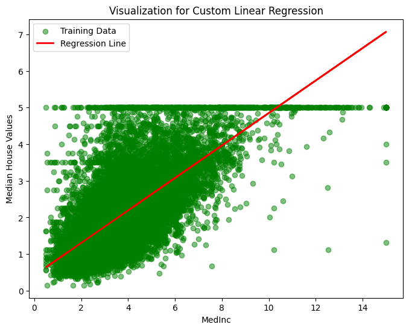

```python
plt.figure(figsize=(8, 6))
plt.scatter(X_train_subset, y_train, color='green', alpha=0.5, label='Training Data')
plt.plot(X_train_subset, y_pred, color='red', linewidth=2, label='Regression Line')
plt.title('Visualization for Custom Linear Regression')
plt.xlabel('MedInc')
plt.ylabel('Median House Values')
plt.legend()
plt.show()
```

To end, let's visualize the performance of the custom linear regresion model on the training data, because visualization give me the warm fuzzies.

In just a few lines of code, we got a score that is similar to what we achieved with the SciKit-Learn implementation.

So what happened? Consider the following formula in which the training data, the estimated coefficients, and the target are terms.

$$ {\displaystyle {\begin{bmatrix}n&\sum _{i=1}^{n}x_{i}\\[1ex]\sum _{i=1}^{n}x_{i}&\sum _{i=1}^{n}x_{i}^{2}\end{bmatrix}}{\begin{bmatrix}{\widehat {\alpha }}\\[1ex]{\widehat {\beta }}\end{bmatrix}}={\begin{bmatrix}\sum _{i=1}^{n}y_{i}\\[1ex]\sum _{i=1}^{n}y_{i}x_{i}\end{bmatrix}}} $$

From the previous can be derived the below. Conveniently, the coefficients to be estimated are isolated on the left-side.

$$ \begin{aligned}{\widehat {\alpha }}&={\frac {\sum \limits _{i=1}^{n}y_{i}\sum \limits _{i=1}^{n}x_{i}^{2}-\sum \limits _{i=1}^{n}x_{i}\sum \limits _{i=1}^{n}x_{i}y_{i}}{n\sum \limits _{i=1}^{n}x_{i}^{2}-\left(\sum \limits _{i=1}^{n}x_{i}\right)^{2}}}\\[2ex]{\widehat {\beta }}&={\frac {n\sum \limits _{i=1}^{n}x_{i}y_{i}-\sum \limits _{i=1}^{n}x_{i}\sum \limits _{i=1}^{n}y_{i}}{n\sum \limits _{i=1}^{n}x_{i}^{2}-\left(\sum \limits _{i=1}^{n}x_{i}\right)^{2}}}\end{aligned} $$

[(Wikipedia)](https://en.wikipedia.org/wiki/Simple_linear_regression)

Unlike other paradigms (e.g., neural networks), a linear regression model is one that can be derived from the data analytically in a reasonable amount of time.

This model can also be interpreted in an intuitive way. After all, it's just a line running through the two variables, signifying their correlation, and it comes pre-packaged with a measure of how far the data is from the line on average. We're going to take advantage of this characteristic in a future post.